# SymPy

### BUSI 520 - Python for Business Research

### Kerry Back, JGSB, Rice University

### SymPy: A Python Library for Symbolic Mathematics

SymPy is a Python library for symbolic mathematics. It aims to become a full-featured computer algebra system (CAS) while keeping the code as simple as possible in order to be comprehensible and easily extensible. SymPy is written entirely in Python and does not require any external libraries.

## How SymPy Works

1. **Symbolic Variables**: In SymPy, you work with symbolic variables, which represent mathematical variables in your expressions. These are different from regular Python variables.
2. **Expressions**: You can build mathematical expressions using symbolic variables and SymPy functions.
3. **Equations**: SymPy can represent equations symbolically, allowing you to solve them analytically or numerically.
4. **Manipulation and Simplification**: SymPy can simplify expressions, expand them, factor them, and perform other algebraic manipulations.
5. **Calculus**: SymPy supports symbolic calculus, including differentiation, integration, and limit calculations.
6. **Solvers**: SymPy contains functions to solve equations algebraically.
7. **Matrix Operations**: SymPy can perform various matrix operations including inverse, determinant, etc.
8. **Plotting**: SymPy can plot expressions and functions.

```python
# Example 1: Defining and Manipulating Symbolic Variables
from sympy import symbols

x, y = symbols('x y')
expr = x + 2*y
expr
```

$\displaystyle x + 2 y$

```python
expr.subs(y, 1)
```

$\displaystyle x + 2$

```python
# Example 2: Solving Equations
from sympy import Eq, solve

sol1 = solve(x**2 - 1, x)
print(sol1)

sol2 = solve([x**2-y**2, x+y], (x, y))
print(sol2)
```

```
[-1, 1]
[(-y, y)]
```

```python
# Example 3: Differentiation
from sympy import diff

expr = x**2 + x*y
diff_expr = diff(expr, x)
diff_expr
```

$\displaystyle 2 x + y$

```python
# Example 4: Integration
from sympy import integrate

expr = x**2
integral_expr = integrate(expr, x)
integral_expr
```

$\displaystyle \frac{x^{3}}{3}$

```python
# Example 5: Matrix Operations
from sympy import Matrix

matrix = Matrix([[1, 2], [3, 4]])
matrix_inv = matrix.inv()
matrix_inv
```

$\displaystyle \left[\begin{matrix}-2 & 1\\\frac{3}{2} & - \frac{1}{2}\end{matrix}\right]$

```python
# Example 6: Solving a Differential Equation
from sympy import Function, dsolve, Derivative, sin

y = Function('y')
diff_eq = Derivative(y(x), x, x) - 2*Derivative(y(x), x) + y(x) - sin(x)
solution = dsolve(diff_eq, y(x))
solution
```

$\displaystyle y{\left(x \right)} = \left(C_{1} + C_{2} x\right) e^{x} + \frac{\cos{\left(x \right)}}{2}$

### Exercise

Execute the following:

```
from sympy import diff, cos, exp
C1, C2 = symbols('C1 C2')
y = (C1 + C2*x) * exp(x) + cos(x)/2
print(y.subs(x, 0))
print(diff(y, x).subs(x, 0))
```

Find $C_1$ and $C_2$ so that $y(0) = y'(0) = 0$.

```python
from sympy import diff, cos, exp

C1, C2 = symbols('C1 C2')
y = (C1 + C2*x) * exp(x) + cos(x)/2
print(y.subs(x, 0))
print(diff(y, x).subs(x, 0))
```

```
C1 + 1/2
C1 + C2
```

```python
# Example 7: lambdify

from sympy import lambdify, cos, exp

y = (-1/2 + (1/2)*x) * exp(x) + cos(x)/2
func = lambdify(x, y)
func(1)
```

```
0.2701511529340699
```

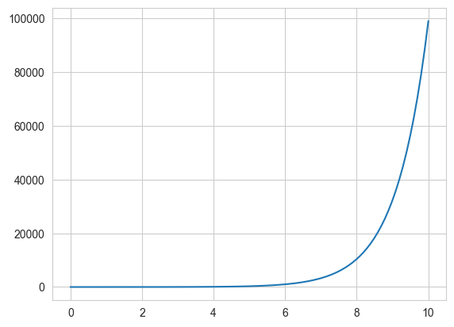

```python
import numpy as np
import matplotlib.pyplot as plt
import seaborn as sns
sns.set_style("whitegrid")

grid = np.linspace(0, 10, 100)
plt.plot(grid, [func(x) for x in grid])
plt.show()
```